# 230308_drugbank_info

Jennifer Fisher

2023-03-08

# START

```
Goal/Purpose of operations:
I am going to be looking at the results from FARES sex-bias adverse event but with the addition of the drug bank infomation

Finished psedocode on:
230308

System which operations were done on:
my laptop

GitHub Repo:
230321_JLF_Sex_bias_adverse_events

Docker:
jenfisher7/rstudio_sex_bias_drugs

Directory of operations:
~/Documents/230321_JLF_Sex_bias_adverse_events

Scripts being edited for operations:
NA

Data being used:
~/results/FARES_plots/drug_ae_res_info.rds - fisher extact test results from FARES database
~/data/full database.xml- drugbank database; version="5.1.8"

Papers and tools:
NA
```

# STEPS

### Set working directory

```r
source("~/src/sex_bias_drug_functions.R")
library(ggplot2)
library(circlize)
library(ComplexHeatmap)
library(drugbankR)
library(DBI)
library(hash)
library(org.Hs.eg.db)
library(stringr)
library(viridis)
library(tidyverse)
drug_ae_res_info <- readRDS("~/results/FARES_plots/drug_ae_res_info.rds")
```

## Analysis

```r
drugbank_dataframe <- dbxml2df(xmlfile="~/data/full database.xml", version="5.1.8")
```

Extracting data for column names. This may take 20 minutes. Successfully convert DrugBank database (xml file) into dataframe.

```r
saveRDS(drugbank_dataframe, "~/data/drug_bank_1_5_8_df.rds")
```

```r
drugbank_dataframe[1:10,]
```

```r
setwd("~/data")
df2SQLite(dbdf=drugbank_dataframe, version="5.1.8")
```

identify drug information on only the significant drugs

```r
drug_ae_res_info_sig <- drug_ae_res_info[drug_ae_res_info$BH < 0.05 & abs(drug_ae_res_info$logROR) > 1,]
```

```r
drug_ids <- unique(drug_ae_res_info_sig$drug)
```

```r
targets <- queryDB(drug_ids ,type = "getTargets", db_path = "~/data/drugbank_5.1.8.db") [,5]
print("done target")
```

```
## [1] "done target"
```

```r
carrier <- getCarriers(drug_ids, db_path = "~/data/drugbank_5.1.8.db")
print("done carrier")
```

```
## [1] "done carrier"
```

```r
transporter <- getTransporter(drug_ids, db_path = "~/data/drugbank_5.1.8.db")
```

```
## [1] 72
## [1] 153
## [1] 153
## [1] 153
```

```r
print("done transporter")
```

```
## [1] "done transporter"
```

```r
enzyme <- getEnzymes(drug_ids, db_path = "~/data/drugbank_5.1.8.db")
print("done enzymes")
```

```
## [1] "done enzymes"
```

```r
drug_info <- cbind(drug_ids, targets, enzyme, transporter, carrier)
```

```r
drug_info<- as.data.frame(drug_info)
```

get information for all the drugs in FARES database

```r
drug_ae_df_inital <- readRDS("~/data/drug_ae_df.rds")
```

```r
inital_drug_list <- unique(drug_ae_df_inital$drug)
```

repeat the process

```r
targets <- queryDB(inital_drug_list ,type = "getTargets", db_path = "~/data/drugbank_5.1.8.db") [,5]
print("done target")
```

```
## [1] "done target"
```

```r
carrier <- getCarriers(inital_drug_list, db_path = "~/data/drugbank_5.1.8.db")
print("done carrier")
```

```
## [1] "done carrier"
```

```r
transporter <- getTransporter(inital_drug_list, db_path = "~/data/drugbank_5.1.8.db")
```

```
## [1] 178
## [1] 178
## [1] 242
## [1] 242
## [1] 242
## [1] 461
## [1] 605
## [1] 880
## [1] 2862
## [1] 2862
## [1] 2862
## [1] 2862
## [1] 2862
## [1] 2862
```

```r
print("done transporter")
```

```
## [1] "done transporter"
```

```r
enzyme <- getEnzymes(inital_drug_list, db_path = "~/data/drugbank_5.1.8.db")
print("done enzymes")
```

```
## [1] "done enzymes"
```

```r
drug_info_all <- cbind(inital_drug_list, targets, enzyme, transporter, carrier)
```

```r
drug_info_all<- as.data.frame(drug_info_all)
```

### Permutation testing- Drug targets

count table of drug target in SBAES

```r
sbae_targets <- unlist(str_split(drug_info[,2], ";"))
sbae_targets <- sbae_targets[!is.na(sbae_targets )]
sbae_targets <- sbae_targets[!sbae_targets == "NA"]
```

```r
sbae_targets_df<- as.data.frame(table(sbae_targets))
```

count table of drug target in all targets

```r
all_targets <- unlist(str_split(drug_info_all[,2], ";"))
all_targets <- all_targets[!is.na(all_targets )]
all_targets <- all_targets[!all_targets == "NA"]
```

```r
all_targets_df<- as.data.frame(table(all_targets))
```

```r
length(all_targets_df$all_targets)
```

```
## [1] 2082
```

2082- total targets

```r
not_sbae_targets_list <- all_targets_df$all_targets[!all_targets_df$all_targets %in% sbae_targets_df$sbae_targets]
```

add 0 counts to target targets that are not used by SBAE drugs

```r
count <- rep(0, length(not_sbae_targets_list))
other_targets <- cbind(as.character(not_sbae_targets_list), count)
colnames(other_targets) <- colnames(sbae_targets_df)
```

```r
sbae_targets_test_df<- rbind(sbae_targets_df, other_targets)
```

test all the drug targets in FARES for enrichment in SBAE drugs

```r
pvalue<- c()
plots<- list()
test<- list()
for ( j in 1:nrow(sbae_targets_test_df)){ #
  print(j)
  res <- drug_gene_test(as.character(sbae_targets_test_df[j,1]),as.numeric(sbae_targets_test_df[j,2]), 2, drug_info_all )
  pvalue[j]<- res[1]
  plots[j]<- res[2]
  test[j]<- res[3]
}
```

```
## [1] 1
## [1] 2
## [1] 3
## [1] 4
## [1] 5
## [1] 6
## [1] 7
## [1] 8
## [1] 9
## [1] 10
## [1] 11
## [1] 12
## [1] 13
## [1] 14
## [1] 15
```

[output cut: 2067 more lines]

```r
names(test)<- sbae_targets_test_df[,1]
```

```r
test_df<- as.data.frame(test)
```

Plot the test results

```r
test_long_df <- pivot_longer(test_df, cols=everything(), names_to = "Drug_Target", values_to = "Count")
```

```r
sbae_targets_test_df$p_adj<-  p.adjust(pvalue, method= "BH")
```

```r
table(sbae_targets_test_df$p_adj < 0.001)
```

```
##
## FALSE  TRUE
##  1256   826
```

Focus on SBAE drug targets that are shared by 6 SBAE drugs

```r
sbae_targets_df_filter <- sbae_targets_test_df[as.numeric(sbae_targets_test_df$Freq) > 5,]
```

```r
dim(sbae_targets_df_filter)
```

```
## [1] 85  3
```

```r
sbae_targets_df_top <-sbae_targets_df_filter[sbae_targets_df_filter$p_adj< 0.001,]
```

```r
dim(sbae_targets_df)
```

```
## [1] 848   2
```

```r
dim(sbae_targets_df_top)
```

```
## [1] 84  3
```

```r
test_long_df_top <- test_long_df[test_long_df$Drug_Target %in% sbae_targets_df_top$sbae_targets, ]
```

```r
sbae_counts<- c()
for(i in 1:nrow(test_long_df_top)){
  sbae_counts[i] <- sbae_targets_df_top$Freq[sbae_targets_df_top$sbae_targets == test_long_df_top$Drug_Target[i]]
}
```

```r
test_long_df_top$Drug_Target <- factor(test_long_df_top$Drug_Target, levels= sbae_targets_df_top$sbae_targets)
```

```r
test_long_df_top$sbae_number <- as.numeric(sbae_counts)
```

```r
test_long_df_top$Drug_Target <- factor(test_long_df_top$Drug_Target, levels =as.character(sbae_targets_df_top$sbae_targets)[order(-as.numeric(sbae_targets_df_top$Freq))])
```

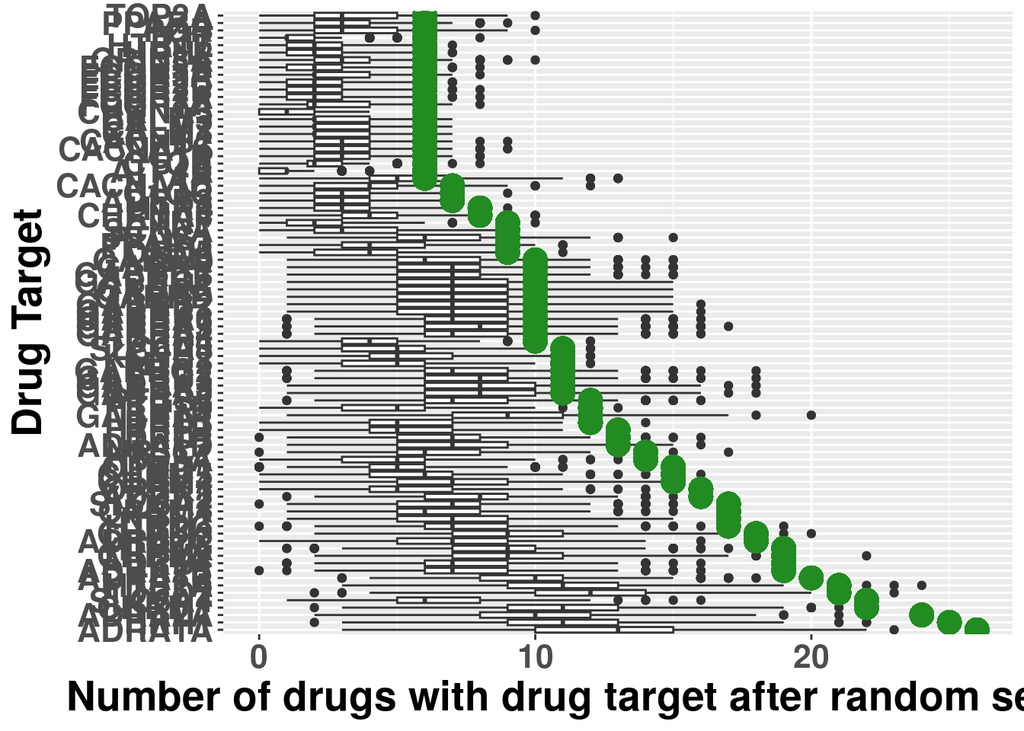

```r
ggplot(test_long_df_top, aes(x=Count, y= Drug_Target ))+ geom_boxplot() + geom_point( aes(y=Drug_Target, x= sbae_number ), color= "forestgreen",size =5) +
  xlab("Number of drugs with drug target after random selection" ) +
  theme(text = element_text(size = 20,  face="bold")) + ylab("Drug Target")
```

```r
ggsave("~/results/FARES_plots/230313_drug_target_box_plot.png", height=20, width = 10)
```

different plot looking at the fraction of drug targets of SBAE and all drugs

```r
sbae_targets_df_top$neg_log_p <- -log(sbae_targets_df_top$p_adj)
```

```r
sbae_targets_df_top <- sbae_targets_df_top[order(-as.numeric(sbae_targets_df_top$Freq)), ]
sbae_targets_df_top$sbae_targets <- factor(sbae_targets_df_top$sbae_targets, levels= sbae_targets_df_top$sbae_targets)
```

```r
all_counts<- c()
for (i in 1:nrow(sbae_targets_df_top)){
  all_counts[i] <- all_targets_df$Freq[unfactor(all_targets_df$all_targets) == sbae_targets_df_top$sbae_targets[i]]
}
```

```r
sbae_targets_df_top$all_count<- all_counts
```

```r
sbae_targets_df_top$fraction <- as.numeric(sbae_targets_df_top$Freq)/sbae_targets_df_top$all_count
```

```r
sbae_targets_df_top$sbae_fraction <- as.numeric(sbae_targets_df_top$Freq)/416 # number of sbae drugs
```

```r
sbae_targets_df_top$all_fraction <- as.numeric(sbae_targets_df_top$all_count)/2945 # number of all. drugs
```

```r
table(sbae_targets_df_top$sbae_fraction > sbae_targets_df_top$all_fraction )
```

```
##
## TRUE
##   84
```

```r
fract_plot_data <- sbae_targets_df_top[, c(1,7,8)]
```

```r
colnames(fract_plot_data)<- c("sbae_targets", "SBAE Drugs" , "All Drugs")
```

```r
fract_plot_data_long <- pivot_longer(fract_plot_data, col = !sbae_targets)
```

```r
fract_plot_data_long$sbae_targets<- factor(fract_plot_data_long$sbae_targets , levels= sbae_targets_df_top$sbae_targets)
```

```r
fract_plot_data_long$name<- factor(fract_plot_data_long$name, levels= c( "SBAE Drugs" , "All Drugs") )
```

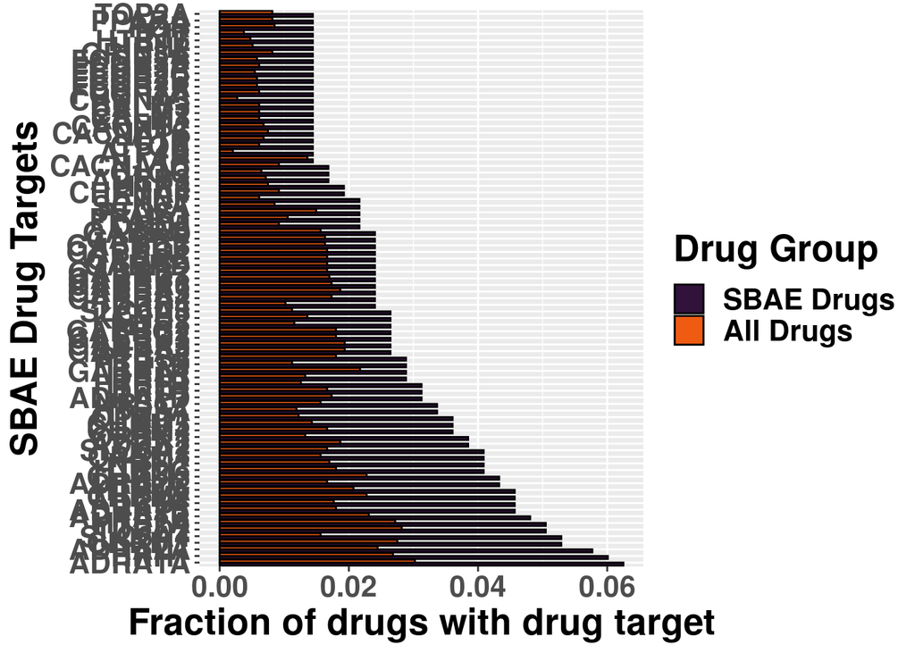

```r
ggplot(fract_plot_data_long, aes(y= sbae_targets, x = value, fill= name))+
    geom_bar(position="dodge", stat="identity", color= "black") +
    scale_fill_viridis(discrete = T, option = "H", end= 0.8, name = "Drug Group") +
    ylab("SBAE Drug Targets") +
    xlab("Fraction of drugs with drug target") +
    theme(text = element_text(size = 20,  face="bold"))
```

```r
ggsave("~/results/FARES_plots/230313_drug_target_bar_plot.png", height=20, width = 10)
```

count table of drug enzymes

```r
sbae_enz <- unlist(str_split(drug_info[,3], ";"))
sbae_enz <- sbae_enz[!is.na(sbae_enz )]
sbae_enz <- sbae_enz[!sbae_enz == "NA"]
sbae_enz <- sbae_enz[!sbae_enz == ""]
```

```r
sbae_enz_df<- as.data.frame(table(sbae_enz))
```

count table of drug target in all targets

```r
all_enz <- unlist(str_split(drug_info_all[,3], ";"))
all_enz <- all_enz[!is.na(all_enz )]
all_enz <- all_enz[!all_enz == "NA"]
```

```r
all_enz_df<- as.data.frame(table(all_enz))
```

```r
length(all_enz_df$all_enz)
```

```
## [1] 345
```

345- total drug metabolism enzymes

```r
not_sbae_enz_list <- all_enz_df$all_enz[!all_enz_df$all_enz %in% sbae_enz_df$sbae_enz]
```

add 0 counts to target targets that are not used by SBAE drugs

```r
count <- rep(0, length(not_sbae_enz_list))
other_enz <- cbind(as.character(not_sbae_enz_list), count)
colnames(other_enz) <- colnames(sbae_enz_df)
```

```r
sbae_enz_test_df<- rbind(sbae_enz_df, other_enz)
```

matrix for each adverse event and drug target

```r
pvalue<- c()
plots2<- list()
test2<- list()
for ( j in 1:nrow(sbae_enz_test_df)){ #
  print(j)
  res <- drug_gene_test(as.character(sbae_enz_test_df[j,1]),as.numeric(sbae_enz_test_df[j,2]), 3, drug_info_all )
  pvalue[j]<- res[1]
  plots2[j]<- res[2]
  test2[j]<- res[3]
  }
```

```
## [1] 1
## [1] 2
## [1] 3
## [1] 4
## [1] 5
## [1] 6
## [1] 7
## [1] 8
## [1] 9
## [1] 10
## [1] 11
## [1] 12
## [1] 13
## [1] 14
## [1] 15
```

[output cut: 168 more lines]

```
## [1] 184
## [1] 185
## [1] 186
## [1] 187
## [1] 188
## [1] 189
## [1] 190
## [1] 191
## [1] 192
## [1] 193
## [1] 194
## [1] 195
## [1] 196
## [1] 197
## [1] 198
```

[output cut: 147 more lines]

```r
sbae_enz_test_df$p_adj<-  p.adjust(pvalue, method= "BH")
```

```r
sbae_enz_df_top <- sbae_enz_df[sbae_enz_test_df$p_adj < 0.001, ]
```

```r
names(test2) <- sbae_enz_test_df[, 1]
```

```r
test2_df <- as.data.frame(test2)
```

```r
test2_long_df <- pivot_longer(test2_df, cols=everything(), names_to = "Drug_Enzyme", values_to = "Count")
```

```r
test2_long_df$Drug_Enzyme<- ifelse(test2_long_df$Drug_Enzyme == "CYP3A7.CYP3A51P", "CYP3A7-CYP3A51P", test2_long_df$Drug_Enzyme)
```

```r
#as.numeric(sbae_enz_test_df$Freq) > 0
test2_long_df_v2 <- test2_long_df[test2_long_df$Drug_Enzyme %in% sbae_enz_test_df$sbae_enz[as.numeric(sbae_enz_test_df$Freq) > 5], ]
```

```r
sbae_counts<- c()
for(i in 1:nrow(test2_long_df_v2 )){
  sbae_counts[i] <- sbae_enz_test_df$Freq[sbae_enz_test_df$sbae_enz == test2_long_df_v2$Drug_Enzyme[i]]
}
```

```r
test2_long_df_v2$sbae_number<- as.numeric(sbae_counts)
```

```r
sbae_enz_df_top<- sbae_enz_df_top[order(-sbae_enz_df_top$Freq),]
test2_long_df_v2$Drug_Enzyme<- factor(test2_long_df_v2$Drug_Enzyme, levels= sbae_enz_df_top$sbae_enz)
```

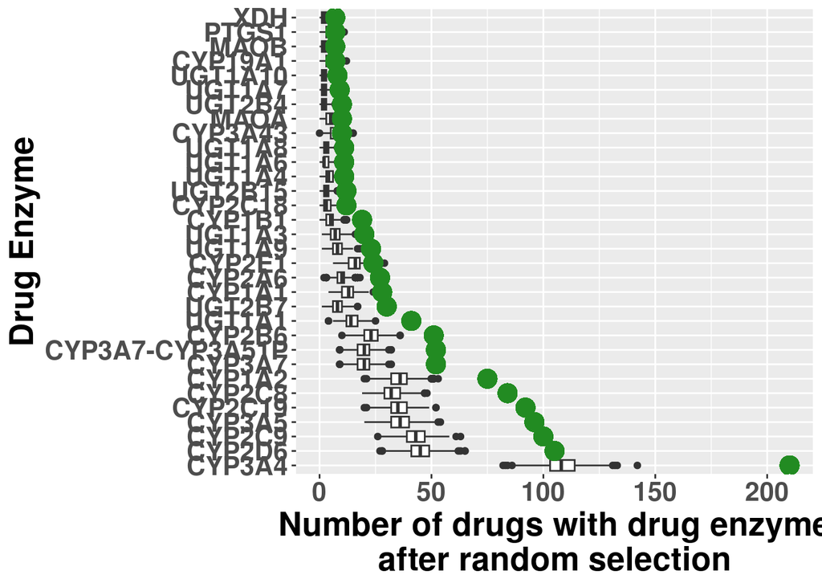

```r
ggplot(test2_long_df_v2, aes(x=Count, y= Drug_Enzyme ))+
  geom_boxplot() +
  geom_point( aes(y=Drug_Enzyme,x= sbae_number ), color= "forestgreen",size =5) +
  xlab("Number of drugs with drug enzyme\nafter random selection" ) +
  theme(text = element_text(size = 20,  face="bold")) + ylab("Drug Enzyme")
```

```r
ggsave("~/results/FARES_plots/230313_drug_enzyme_box_plot.png", height=20, width = 10)
```

Number of significant drug metabolism enzymes with more than 5 drugs with the enzyme

```r
length(unique(test2_long_df_v2$Drug_Enzyme))
```

```
## [1] 32
```

Look at the fraction of drug with drug enzyme in SBAE and all drugs

```r
all_enz <- unlist(str_split(drug_info_all[,3], ";"))
all_enz <- all_enz[!is.na(all_enz )]
all_enz <- all_enz[!all_enz == "NA"]
```

```r
all_enz_df<- as.data.frame(table(all_enz))
```

```r
sbae_enz_df_top<- sbae_enz_df_top[sbae_enz_df_top$Freq > 5,]
```

```r
all_counts<- c()
for (i in 1:nrow(sbae_enz_df_top)){
  all_counts[i] <- all_enz_df$Freq[ unfactor(all_enz_df$all_enz) == sbae_enz_df_top$sbae_enz[i]]
}
```

```r
sbae_enz_df_top$all_count<- all_counts
```

```r
sbae_enz_df_top$sbae_fraction <- as.numeric(sbae_enz_df_top$Freq)/416 # number of sbae drugs
```

```r
sbae_enz_df_top$all_fraction <- as.numeric(sbae_enz_df_top$all_count)/2945 # number of all. drugs
```

```r
table(sbae_enz_df_top$sbae_fraction > sbae_enz_df_top$all_fraction )
```

```
##
## TRUE
##   32
```

```r
fract_plot_data <- sbae_enz_df_top[, c(1,4,5)]
```

```r
colnames(fract_plot_data)<- c("sbae_enz", "SBAE Drugs" , "All Drugs")
```

```r
fract_plot_data_long <- pivot_longer(fract_plot_data, col = !sbae_enz)
```

```r
fract_plot_data_long$sbae_enz <- factor(fract_plot_data_long$sbae_enz , levels= sbae_enz_df_top$sbae_enz)
```

```r
fract_plot_data_long$name<- factor(fract_plot_data_long$name, levels= c( "SBAE Drugs" , "All Drugs") )
```

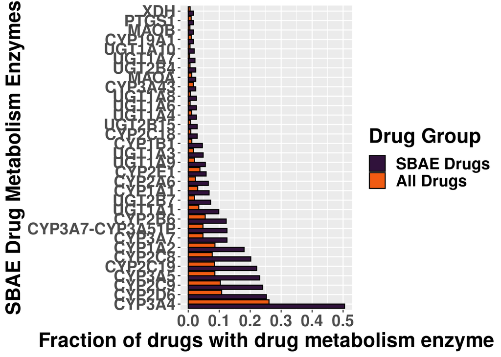

```r
ggplot(fract_plot_data_long, aes(y= sbae_enz, x = value, fill= name))+
    geom_bar(position="dodge", stat="identity", color= "black") +
    scale_fill_viridis(discrete = T, option = "H", end= 0.8, name = "Drug Group") +
    ylab("SBAE Drug Metabolism Enzymes") +
    xlab("Fraction of drugs with drug metabolism enzyme") +
    theme(text = element_text(size = 20,  face="bold"))
```

```r
ggsave("~/results/FARES_plots/230313_drug_enzyme_bar_plot.png", height=20, width = 10)
```

save everything here…

```r
saveRDS(sbae_targets_df_top, "~/results/FARES_plots/sbae_targets_df_top.rds")
saveRDS(sbae_enz_df_top, "~/results/FARES_plots/sbae_enz_df_top.rds")
saveRDS(drug_info_all,"~/results/FARES_plots/drug_info_all.rds" )
saveRDS(drug_info, "~/results/FARES_plots/drug_info_sbae_drugs.rds")
```

```r
saveRDS(plots,"~/results/FARES_plots/sbae_targets_plots.rds" )
saveRDS(test,"~/results/FARES_plots/sbae_targets_test.rds" )
saveRDS(plots2,"~/results/FARES_plots/sbae_enzyme_plots.rds" )
saveRDS(test2,"~/results/FARES_plots/sbae_enzyme_test.rds" )
```

# END

```
Location of final scripts:
src
Location of data produced:
~/results/FARES_plots
Dates when operations were done:
230418
```